# RNA-Seq vs Microarrays

## Goals and research questions

1. Compare two gene expression platforms: RNA-Seq and microarrays.
   - Determine the subset of genes that are measured by both platforms.
     - Determine the correlation between them.
   - What is being measured by arrays but not by sequencing?
   - What is being measured by sequencing but not by arrays?
2. Determine the most **relevant early gene** expression changes that take place in the circulating immune system of monkeys infected with hemorrhagic fever viruses.
   - Which of these relevant and early genes respond differently to each virus? (biomarkers)
3. Determine the most **relevant early non-coding** expression changes that take place in the circulating immune system of monkeys infected with hemorrhagic fever viruses.
   - Which of these relevant and early non-coding regions respond differently to each virus?

## Sequencing data metrics

There are three main stages of processing: 1. **Raw**: the reads that come out of the sequencer, without any filtering. 2. **Mapped Uniquely**: reads that align uniquely a region in the genome (3 billion bp). 3. **Mapped Gene**: reads that align uniquely a region in a gene (1.6% encodes a gene, 44 million bp).

Sequencing samples from each virus group show similar number of reads at every stage of processing (see below). The number of reads that map uniquely to genes remains constant throughout both infections (23 ± 4 million reads). This indicates that **sequencing performs consistently**.

[interactive chart not shown]

## Gene expression analysis

We normalize by using the Trimmed Mean of M-values method (TMM)

The expression of a gene in a sample is measured by counting the number of cDNA reads that align to the location of that gene in the genome. This number is the raw **gene count**, which we normalize to compensate for differences in the total number of cDNA reads in each sample. This ensures that **the gene counts of different samples are comparable**.

Logarithms make it possible to compare values across many orders of magnitude.

In the figure below, each dot corresponds to a gene. The y axis represents the change in expression of that gene 3 days after the monkeys were infected (compared to its pre-infection value). It is calculated by averaging the count values for that gene in all the samples collected 3 days after infection, and dividing by the average of those that were collected before infection \(\frac{day 3}{day 0}\).

Counts per million, or **CPM**s, make it easy to compare gene counts across different samples. They are calculated by multiplying the gene count of a sample by a million, and dividing it by the total number of reads of that sample. Example: a gene has 120 counts in sample A, which has 30 million total counts, therefore the gene has `120 * 1e6 / 30e6 = 4` CPMs.

For the figures in the left, the x axis compares this fold change with the average magnitude (using CPMs, see aside) \(\frac{day 3 + day 0}{2}\) to rank the fold changes by the size of their average gene counts. For the figures in the right, the x axis represents the **significance** of that fold change, taking into account the variability across the replicates, and their average magnitude.

The figures on the left can be interpreted as an airplane view of a deep valley (red being the deepest part), and those on the right ones as the view from the ground (turned on its side, blue is the tallest part)

#### Lassa

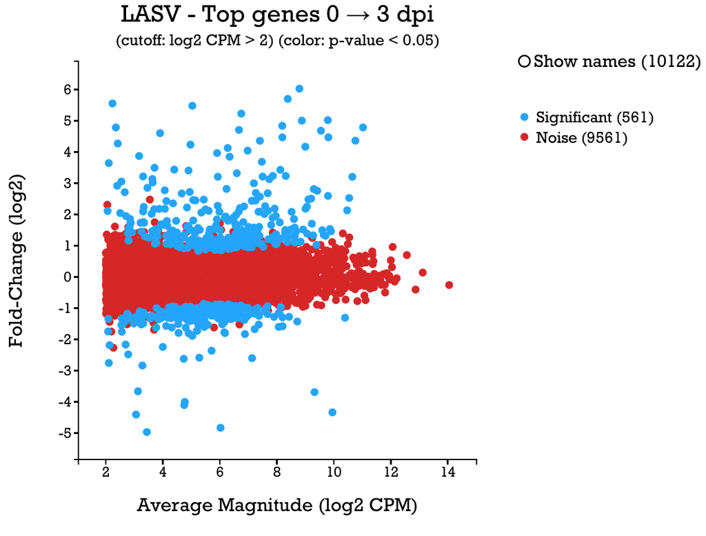

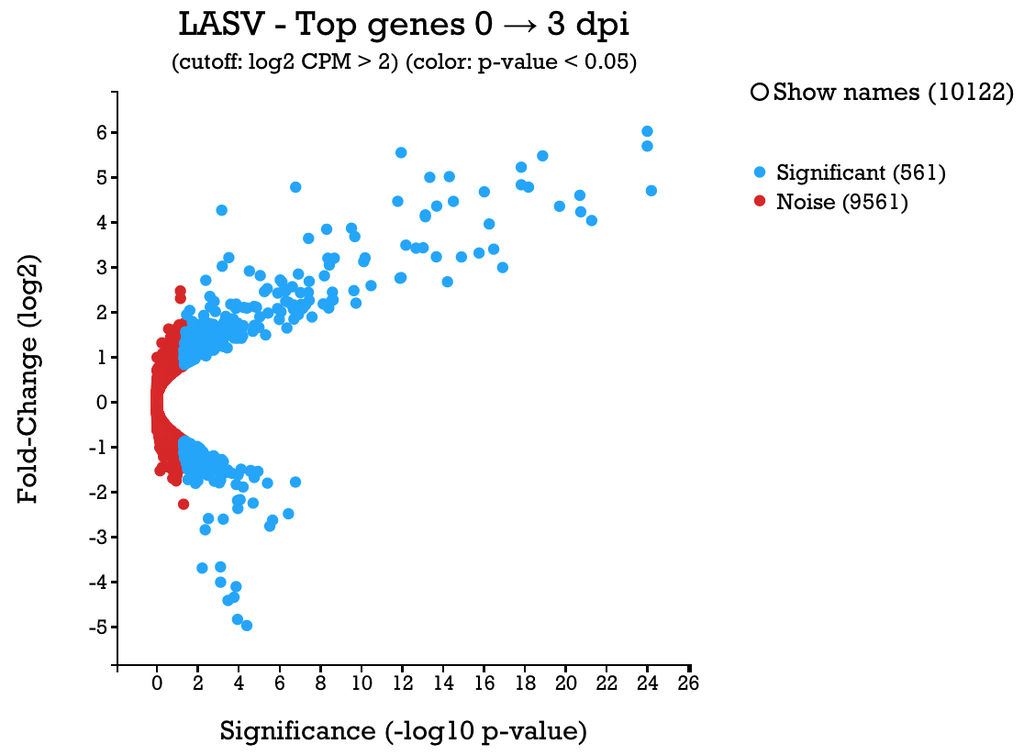

#### Marburg

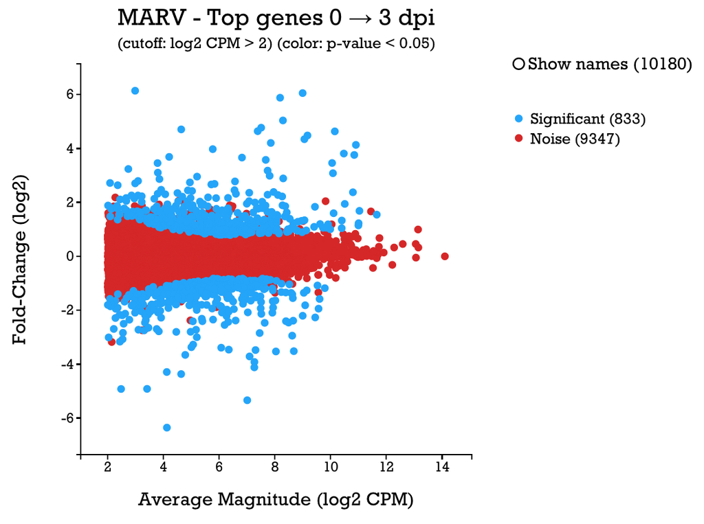

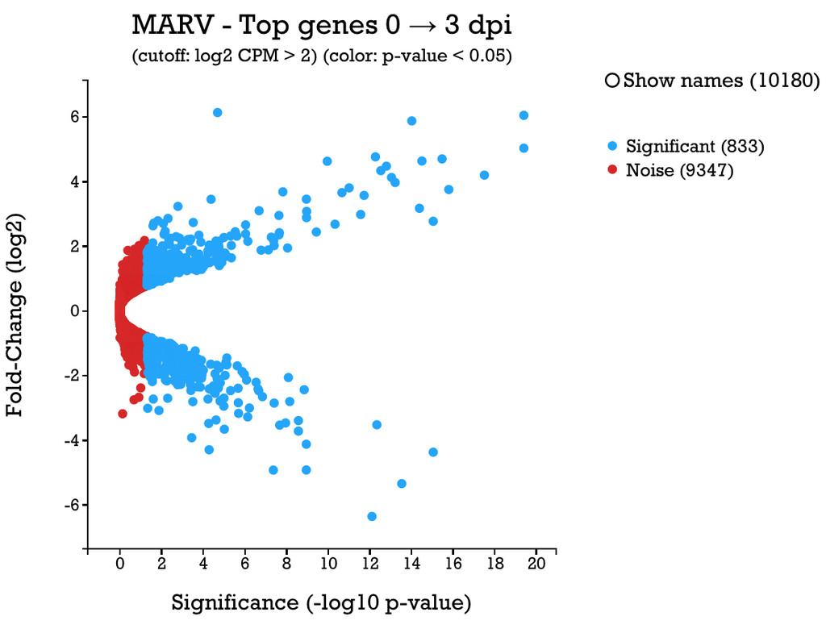

Placing a **significance boundary** lets us distinguish the small subset of genes that strongly change their expression in response to an infection, from the majority whose moderate change in expression is due to chance. These figures illustrate the expression landscape and help ensure that the boundaries have been placed sensibly.

## Comparison between sequencing and arrays

I painfully curated the 25,000 gene annotations used by each platform by combining five different data sources from EBI, NCBI, UCSC and Agilent.

While 15,000 genes are present in both platforms, 10,000 seem to be platform-specific. This is mainly due to naming differences in poorly characterized genes (Agilent probe ids, ESTs, LOCs, ENST ids, UTRs) and, but also to the lack of non-coding genes in the array and, to a lesser extent, because of gene differences between species (although the RNA was extracted from cynos, it was hybridized in human microarrays, and sequence-aligned to the rhesus genome).

Surprisingly, the majority of platform-specific genes have a fold change smaller than 2 (see below). The small fraction of platform-specific genes with high fold changes is mainly composed of uncharacterized genes (except for MX2, APOBEC3B, USP41, IL27, EIF2AK2 and CCDC162P, interferon stimulated genes, which are picked up by human array probes, but are not annotated in the rhesus genome). This provides evidence that **both platforms are comparable**.

#### Lassa

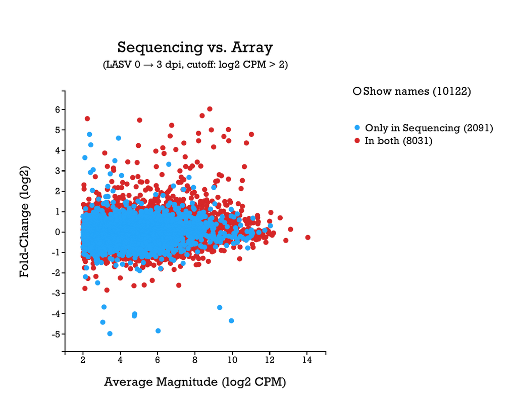

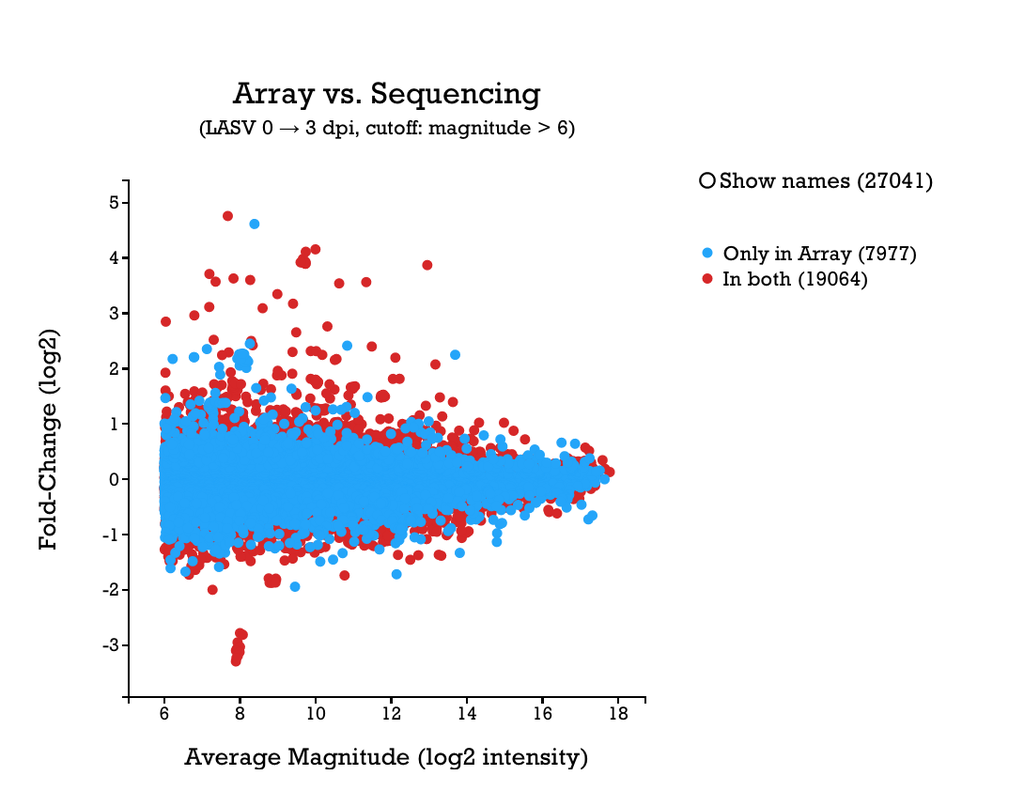

#### Marburg

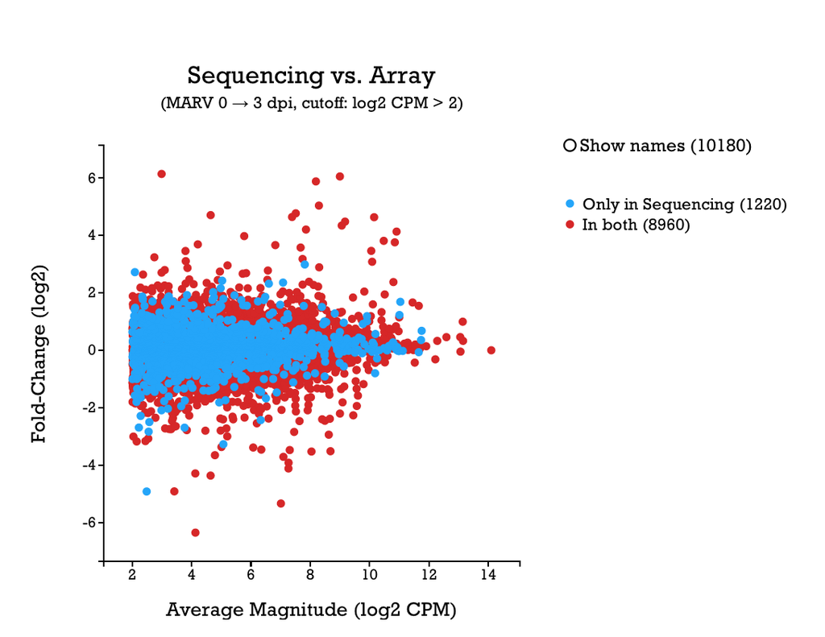

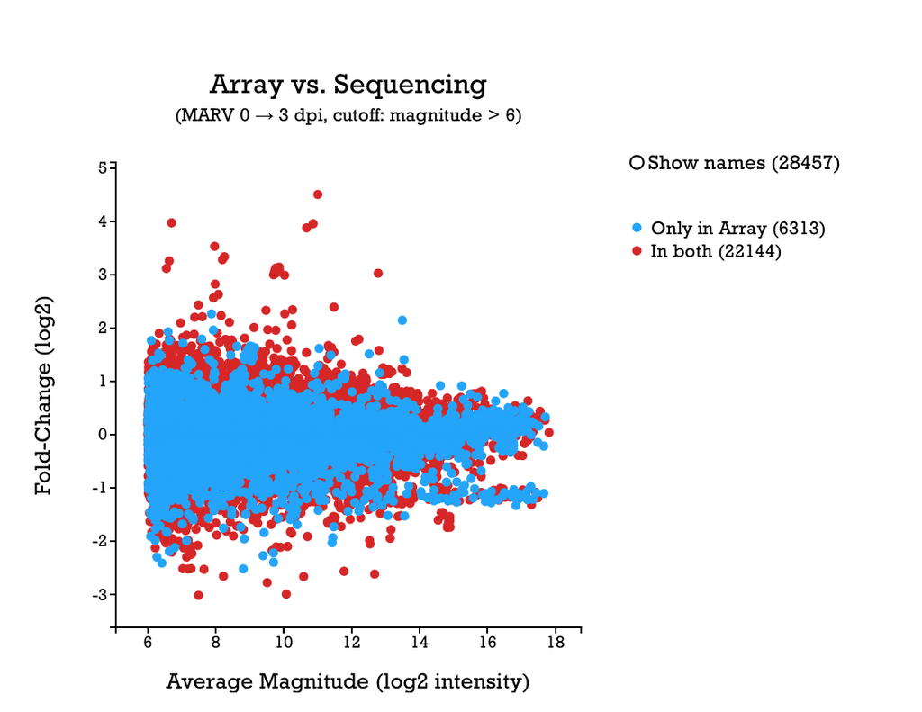

Arrays have multiple probes per gene, and the rhesus ensembl annotation has multiple gene ids for some genes (ex: HOXC11, KRT27), so it is not always obvious what probes should be compared with what genes. An alternative to using medians is duplicating genes whenever an array probe lacks a sequencing id, or viceversa. This is shown in the figure below. For both Lassa and Marburg, among the common genes that are identified as significant in at least one platform, the **correlation is high**.

The vertical stretches are caused by annotation artifacts (for example, Y RNAs have not been assigned unique gene names). Genes that are sequencing-specific and that fall on the diagonal, show the same behavior in the arrays but with higher variance.

[interactive chart not shown]

These figures illustrate what we already knew:

- The agreement between sequencing and arrays is high.
- Sequencing provides smaller variance (and therefore, better p-values).

[interactive chart not shown]

## Biomarker analysis

Summary of the LASV early response

- Strongly upregulated interferon response (but no upregulation of interferon).
- Chemokines like CCL8, CXCL10, IL1RN, TNFSF10 are strongly upregulated, while IFNG, and IL8 are downregulated.
- Transcriptional regulators like IRF7, IRF9, STAT1, STAT2, TRIM25, BATF2 and PML are strongly upregulated, while EGR2 is downregulated.

Summary of the MARV early response

- Strongly upregulated interferon response (but no upregulation of interferon).
- Chemokines like CCL8, CXCL10, CXCL11, CD40LG, CX3CR1, IL6, CXCR6, and IL1RN are strongly upregulated, while TNF, OSM, IL8, CXCR4, IL1R2, are downregulated.
- Transcriptional regulators like IRF2, IRF7, STAT1, STAT2, BATF2 and PML are strongly upregulated, while FOS, JUNB, FOSL2, CEBPA and ATF4 are strongly downregulated.

[interactive chart not shown]

## Biomarker analysis

Both platforms agree on CMPK2, SIGLEC1, SAMD4A, HSPA1B, BIRC3, NR4A2, JUN, PLK3, SIK1, PFKFB3, CETN3 and CXCR4.

Using RNA-Seq we see that ~100 genes behave differently (4-fold or higher difference) in response to each virus. Depending on the boundary we use to categorize a gene as a biomarker, the overlap with the biomarkers inferred from the array data is of ~12-20 genes.

[interactive chart not shown]

The following figures show some examples biomarkers.

[interactive chart not shown]

The entire list of genes worth validating with RT-PCR

```
RNASEP_NUC
7SK
5S_RRNA
ENSMMUG00000037213_MIRNA
C1ORF74
AREGB
RGS16
ENSMMUG00000035607_MIRNA
U2
ADM
NR4A3
5_8S_RRNA
U2
HSPA1B
NR4A2
TP53INP2
SIGLEC1
ENSMMUG00000012379_PROTEIN_CODING
DEFB1
PLK3
PER1
ARHGEF39
GRASP
JUN
B3GNT7
LOC722929
KEL
VEGFA
LOC718993
OSM
GZMA
ALAS2
SIK1
COL11A1
BIRC3
SOCS1
HBA2
CETN3
IFNG
IGJ
PIM3
CD40LG
SNORA67
ENSMMUG00000029391_PROTEIN_CODING
SUCNR1
AGRN
KBTBD12
SERPINE2
HSPA1L
ENSMMUG00000013326_PROTEIN_CODING
ZNF296
HEMGN
GADD45A
TRIB3
TREM1
SMAD7
FOSL2
KLF10
IGIP
CXCR4
LTB4R
BHLHE40
NR4A1
ENSMMUG00000031104_PROTEIN_CODING
ENPP4
STEAP4
CEBPA
ARID5A
KLF11
S1PR1
PFKFB3
ZNF473
ZNF628
SEMA7A
HSPB1
GADD45B
GAPT
CENPF
CMPK2
JUNB
ENSMMUG00000012514_PSEUDOGENE
GPR113
CDK5R1
HIST1H2AC
SMOX
FOS
SAMD4A
THEMIS2
SLC2A1
IRF2BPL
IER2
STRC
LOC693438
LPAR6
ENSMMUG00000013093_PROTEIN_CODING
RGS1
CD83
ENSMMUG00000003214_PROTEIN_CODING
DDIT3
LONRF3
CXHXORF21
ENSMMUG00000016606_PROTEIN_CODING
ENSMMUG00000030172_PSEUDOGENE
F2R
SLC2A14
CSRNP1
MICALL2
HSD3B7
NFKBIA
SETD1B
PSAT1
TNF
BET1
```